# Lab 0

## EXERCISE 2

Is there an apparent trend in the number of girls baptized over the years? How would you describe it?

## Add the vector for baptisms for boys and girls

```r
arbuthnot$boys + arbuthnot$girls
```

```
##  [1]  9901  9315  8524  9584  9997  9855 10034  9522  9160 10311 10150
## [12] 10850 10670 10370  9410  8104  7966  7163  7332  6544  5825  5612
## [23]  6071  6128  6155  6620  7004  7050  6685  6170  5990  6971  8855
## [34] 10019 10292 11722  9972  8997 10938 11633 12335 11997 12510 12563
## [45] 11895 11851 11775 12399 12626 12601 12288 12847 13355 13653 14735
## [56] 14702 14730 14694 14951 14588 14771 15211 15054 14918 15159 13632
## [67] 13976 14861 15829 16052 15363 14639 15616 15687 15448 11851 16145
## [78] 15369 16066 15862 15220 14928
```

## Plot of the total number of baptisms per year with the command

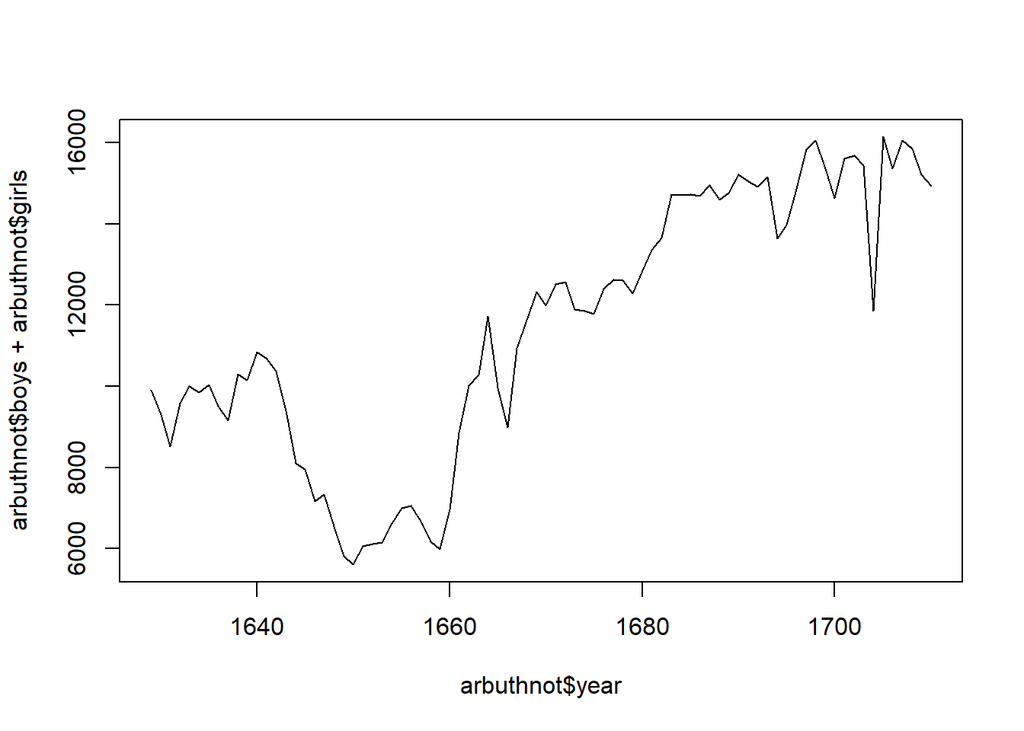

```r
plot(arbuthnot$year, arbuthnot$boys + arbuthnot$girls, type = "l")
```

## The proportion of newborns that are boys

```r
arbuthnot$boys / (arbuthnot$boys + arbuthnot$girls)
```

```
##  [1] 0.5270175 0.5215244 0.5187705 0.5210768 0.5159548 0.5109082 0.5088698
##  [8] 0.5163831 0.5134279 0.5197362 0.5286700 0.5085714 0.5126523 0.5265188
## [15] 0.5093518 0.5067868 0.5080341 0.5260366 0.5177305 0.5139059 0.5285837
## [22] 0.5149679 0.5322023 0.5254569 0.5192526 0.5197885 0.5218447 0.5202837
## [29] 0.5080030 0.5116694 0.5357262 0.5342132 0.5361942 0.5206108 0.5257482
## [36] 0.5153557 0.5128359 0.5199511 0.5134394 0.5220493 0.5274422 0.5232975
## [43] 0.5155076 0.5128552 0.5105507 0.5158214 0.5144798 0.5284297 0.5087122
## [50] 0.5212285 0.5083822 0.5096910 0.5108199 0.5060426 0.5142178 0.5152360
## [57] 0.5080788 0.5155165 0.5174905 0.5132301 0.5147925 0.5199527 0.5089677
## [64] 0.5095857 0.5063659 0.5123973 0.5196766 0.5135590 0.5093183 0.5249190
## [71] 0.5149385 0.5176583 0.5188268 0.5119526 0.5026541 0.5158214 0.5181790
## [78] 0.5174052 0.5215362 0.5194175 0.5151117 0.5117899
```

## EXERCISE 3

Answer 3:

plot of the proportion of boys over time create a regression line to analyze the proportion over time

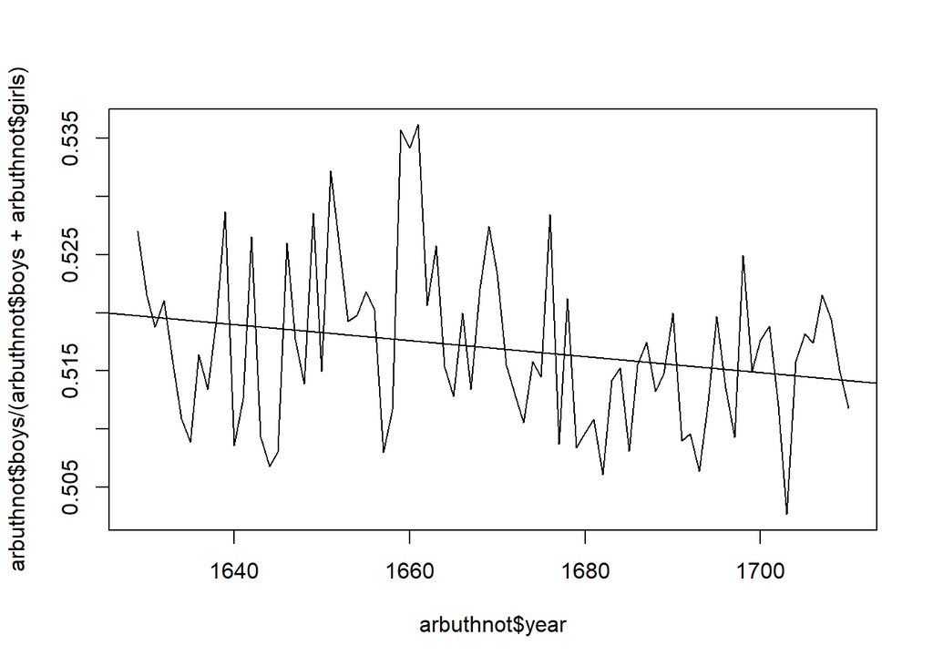

```r
plot(arbuthnot$boys / (arbuthnot$boys + arbuthnot$girls)~arbuthnot$year, type = "l",data=arbuthnot)
abline(lm(arbuthnot$boys / (arbuthnot$boys + arbuthnot$girls) ~ arbuthnot$year,data=arbuthnot))
```

plot of the proportion of girls over time create a regression line to analyze the proportion over time

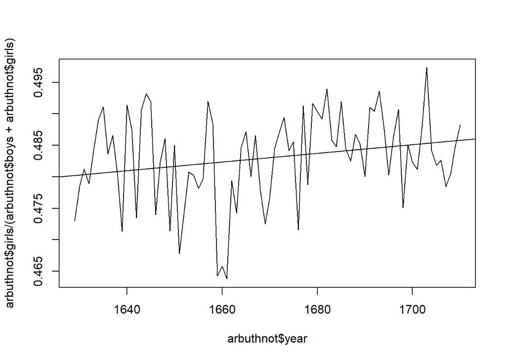

```r
plot(arbuthnot$girls / (arbuthnot$boys + arbuthnot$girls)~arbuthnot$year, type = "l")
abline(lm(arbuthnot$girls / (arbuthnot$boys + arbuthnot$girls) ~ arbuthnot$year))
```

## Do boys outnumber girls in each year

```r
arbuthnot$boys > arbuthnot$girls
```

```
##  [1] TRUE TRUE TRUE TRUE TRUE TRUE TRUE TRUE TRUE TRUE TRUE TRUE TRUE TRUE
## [15] TRUE TRUE TRUE TRUE TRUE TRUE TRUE TRUE TRUE TRUE TRUE TRUE TRUE TRUE
## [29] TRUE TRUE TRUE TRUE TRUE TRUE TRUE TRUE TRUE TRUE TRUE TRUE TRUE TRUE
## [43] TRUE TRUE TRUE TRUE TRUE TRUE TRUE TRUE TRUE TRUE TRUE TRUE TRUE TRUE
## [57] TRUE TRUE TRUE TRUE TRUE TRUE TRUE TRUE TRUE TRUE TRUE TRUE TRUE TRUE
## [71] TRUE TRUE TRUE TRUE TRUE TRUE TRUE TRUE TRUE TRUE TRUE TRUE
```

```r
## yes
```

## Analyzing present day birth records dataset in United States using basic R commands

1. Load the dataset

```r
source("more/present.R")
```

2. View the dataset

```r
present
```

```
##    year    boys   girls
## 1  1940 1211684 1148715
## 2  1941 1289734 1223693
## 3  1942 1444365 1364631
## 4  1943 1508959 1427901
## 5  1944 1435301 1359499
## 6  1945 1404587 1330869
## 7  1946 1691220 1597452
## 8  1947 1899876 1800064
## 9  1948 1813852 1721216
## 10 1949 1826352 1733177
## 11 1950 1823555 1730594
## 12 1951 1923020 1827830
## 13 1952 1971262 1875724
## 14 1953 2001798 1900322
```

[output cut: 49 more lines]

3)Dimensions of the dataset

```r
dim(present)
```

```
## [1] 63  3
```

4)Names of columns of the present Dataset

```r
names(present)
```

```
## [1] "year"  "boys"  "girls"
```

## Number of boys born each year

```r
present$boys
```

```
##  [1] 1211684 1289734 1444365 1508959 1435301 1404587 1691220 1899876
##  [9] 1813852 1826352 1823555 1923020 1971262 2001798 2059068 2073719
## [17] 2133588 2179960 2152546 2173638 2179708 2186274 2132466 2101632
## [25] 2060162 1927054 1845862 1803388 1796326 1846572 1915378 1822910
## [33] 1669927 1608326 1622114 1613135 1624436 1705916 1709394 1791267
## [41] 1852616 1860272 1885676 1865553 1879490 1927983 1924868 1951153
## [49] 2002424 2069490 2129495 2101518 2082097 2048861 2022589 1996355
## [57] 1990480 1985596 2016205 2026854 2076969 2057922 2057979
```

## EXERCISE 1

What command would you use to extract just the counts of girls born?

Answer 1:

```r
present$girls
```

```
##  [1] 1148715 1223693 1364631 1427901 1359499 1330869 1597452 1800064
##  [9] 1721216 1733177 1730594 1827830 1875724 1900322 1958294 1973576
## [17] 2029502 2074824 2051266 2071158 2078142 2082052 2034896 1996388
## [25] 1967328 1833304 1760412 1717571 1705238 1753634 1816008 1733060
## [33] 1588484 1528639 1537844 1531063 1543352 1620716 1623885 1703131
## [41] 1759642 1768966 1794861 1773380 1789651 1832578 1831679 1858241
## [49] 1907086 1971468 2028717 2009389 1982917 1951379 1930178 1903234
## [57] 1901014 1895298 1925348 1932563 1981845 1968011 1963747
```

## Create a simple plot of the number of girls born per year with the command

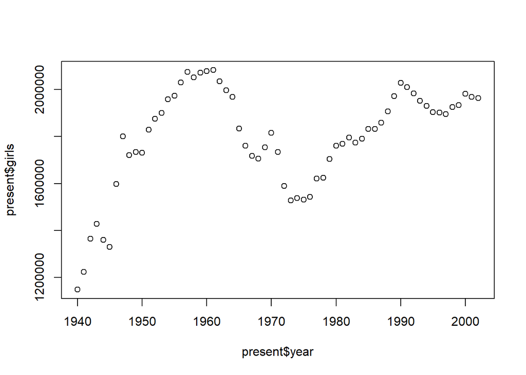

```r
plot(x = present$year, y = present$girls)
```

The first argument in the plot function specifies the variable for the x-axis and the second for the y-axis. If we wanted to connect the data points with lines, we could add a third argument, the letter l for line.

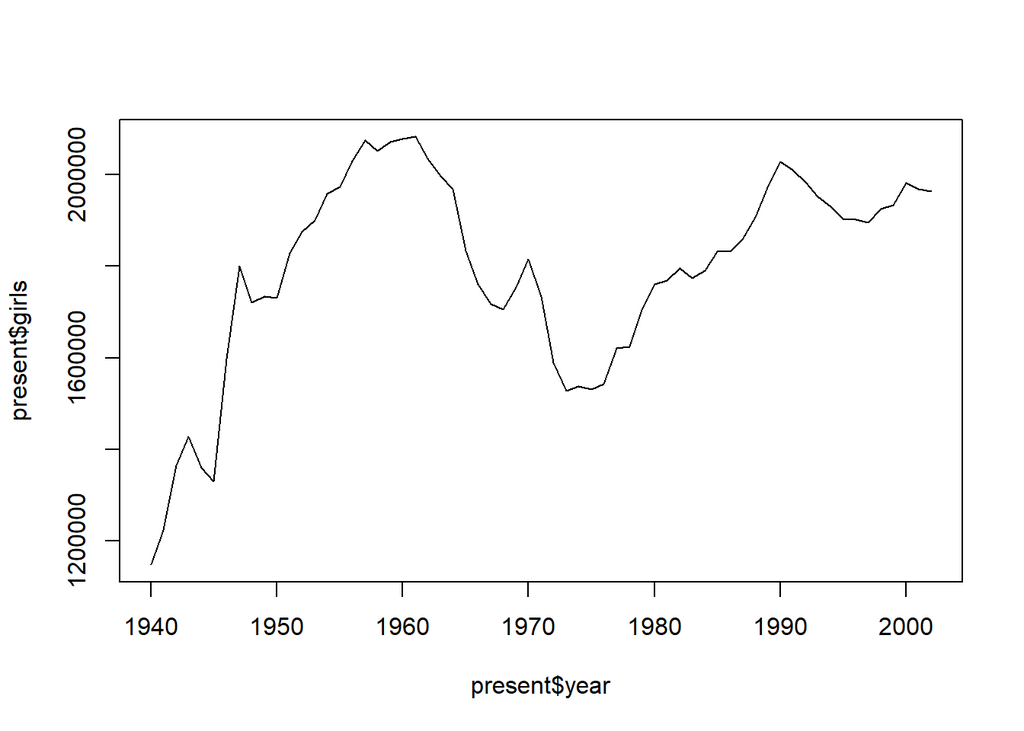

```r
plot(x = present$year, y = present$girls, type = "l")
```

## EXERCISE 2

Is there an apparent trend in the number of girls baptized over the years? How would you describe it?

## Add the vector for birth for boys and girls

```r
present$boys + present$girls
```

```
##  [1] 2360399 2513427 2808996 2936860 2794800 2735456 3288672 3699940
##  [9] 3535068 3559529 3554149 3750850 3846986 3902120 4017362 4047295
## [17] 4163090 4254784 4203812 4244796 4257850 4268326 4167362 4098020
## [25] 4027490 3760358 3606274 3520959 3501564 3600206 3731386 3555970
## [33] 3258411 3136965 3159958 3144198 3167788 3326632 3333279 3494398
## [41] 3612258 3629238 3680537 3638933 3669141 3760561 3756547 3809394
## [49] 3909510 4040958 4158212 4110907 4065014 4000240 3952767 3899589
## [57] 3891494 3880894 3941553 3959417 4058814 4025933 4021726
```

## Plot of the total number of births per year with the command

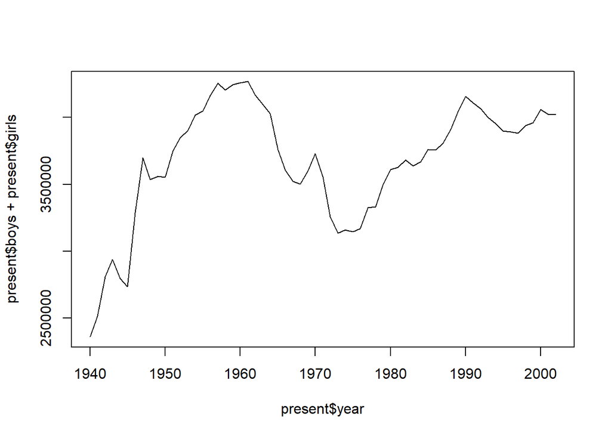

```r
plot(present$year, present$boys + present$girls, type = "l")
```

## The proportion of newborns that are boys

```r
present$boys / (present$boys + present$girls)
```

```
##  [1] 0.5133386 0.5131376 0.5141926 0.5138001 0.5135613 0.5134745 0.5142562
##  [8] 0.5134883 0.5131024 0.5130881 0.5130778 0.5126891 0.5124173 0.5130027
## [15] 0.5125423 0.5123716 0.5125011 0.5123550 0.5120462 0.5120713 0.5119269
## [22] 0.5122088 0.5117064 0.5128408 0.5115250 0.5124656 0.5118474 0.5121866
## [29] 0.5130068 0.5129073 0.5133154 0.5126337 0.5124973 0.5127013 0.5133340
## [36] 0.5130513 0.5127982 0.5128057 0.5128266 0.5126110 0.5128692 0.5125792
## [43] 0.5123372 0.5126648 0.5122425 0.5126849 0.5124035 0.5121951 0.5121931
## [50] 0.5121286 0.5121179 0.5112054 0.5121992 0.5121845 0.5116894 0.5119398
## [57] 0.5114951 0.5116337 0.5115255 0.5119072 0.5117182 0.5111665 0.5117154
```

## EXERCISE 3

Answer 3: plot of the proportion of boys over time create a regression line to analyze the proportion over time

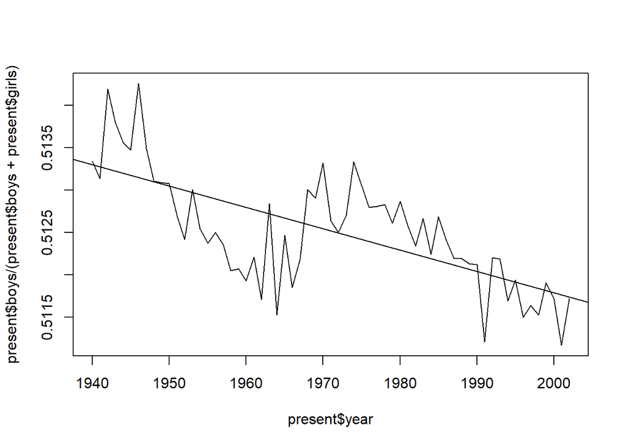

```r
plot( present$boys / (present$boys + present$girls)~present$year, type = "l")
abline(lm(present$boys / (present$boys + present$girls) ~ present$year))
```

plot of the proportion of girls over time create a regression line to analyze the proportion over time

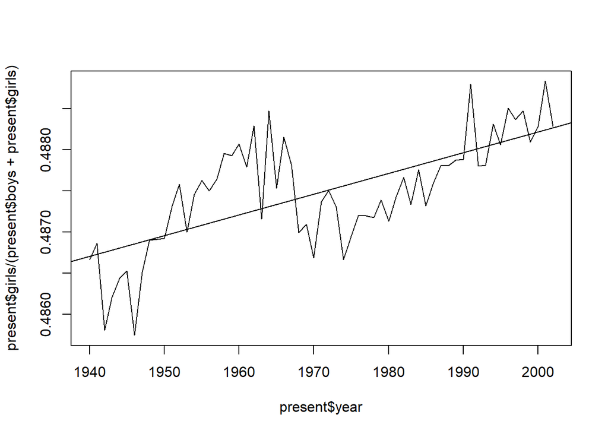

```r
plot(present$girls / (present$boys + present$girls)~present$year, type = "l")
abline(lm(present$girls / (present$boys + present$girls) ~ present$year))
```

## Do boys outnumber girls in each year ?

```r
present$boys > present$girls
```

```
##  [1] TRUE TRUE TRUE TRUE TRUE TRUE TRUE TRUE TRUE TRUE TRUE TRUE TRUE TRUE
## [15] TRUE TRUE TRUE TRUE TRUE TRUE TRUE TRUE TRUE TRUE TRUE TRUE TRUE TRUE
## [29] TRUE TRUE TRUE TRUE TRUE TRUE TRUE TRUE TRUE TRUE TRUE TRUE TRUE TRUE
## [43] TRUE TRUE TRUE TRUE TRUE TRUE TRUE TRUE TRUE TRUE TRUE TRUE TRUE TRUE
## [57] TRUE TRUE TRUE TRUE TRUE TRUE TRUE
```

```r
## yes
```

## Questions

1. What years are included in this data set? What are the dimensions of the data frame and what are the variable or column names?

```r
head(present)
```

```
##   year    boys   girls
## 1 1940 1211684 1148715
## 2 1941 1289734 1223693
## 3 1942 1444365 1364631
## 4 1943 1508959 1427901
## 5 1944 1435301 1359499
## 6 1945 1404587 1330869
```

```r
tail(present)
```

```
##    year    boys   girls
## 58 1997 1985596 1895298
## 59 1998 2016205 1925348
## 60 1999 2026854 1932563
## 61 2000 2076969 1981845
## 62 2001 2057922 1968011
## 63 2002 2057979 1963747
```

```r
dim(present)
```

```
## [1] 63  3
```

```r
names(present)
```

```
## [1] "year"  "boys"  "girls"
```

Answer 1) The years included in this dataset are: 1940 to 2002

2. How do these counts compare to Arbuthnot’s? Are they on a similar scale?

Answer2) Arbuthnot and present datasets are similar for the following cases:  
Both have same no. of columns and same column names Both datasets are analyzing the birth of boys and girls over time.

Arbuthnot and present datasets differ in their counts: When we calculate the mean their is a difference in the counts of both the datasets.

arbuthnot’s mean

```r
mean(arbuthnot$boys + arbuthnot$girls)
```

```
## [1] 11441.74
```

present’s mean

```r
mean(present$boys + present$girls)
```

```
## [1] 3679515
```

3. Make a plot that displays the boy-to-girl ratio for every year in the data set. What do you see? Does Arbuthnot’s observation about boys being born in greater proportion than girls hold up in the U.S.? Include the plot in your response.

Answer 3)

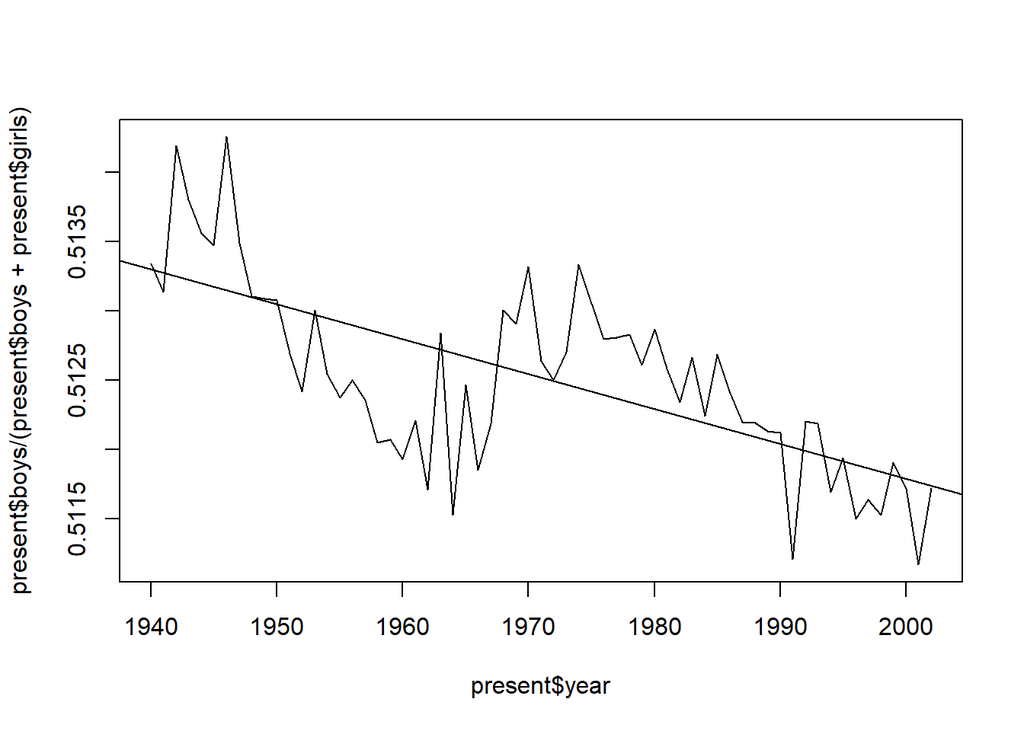

```r
plot(present$year, present$boys / (present$boys + present$girls), type = "l")
abline(lm(present$boys / (present$boys + present$girls) ~ present$year))
```

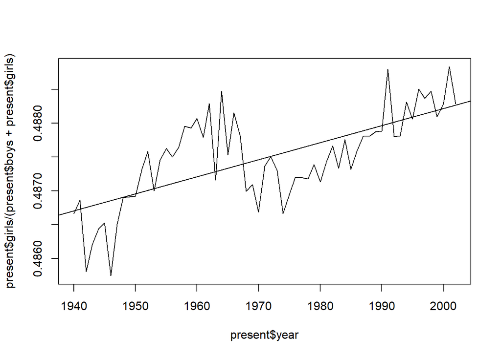

```r
plot(present$year, present$girls / (present$boys + present$girls), type = "l")
abline(lm(present$girls / (present$boys + present$girls) ~ present$year))
```

Therefore Arbuthnot’s observation about boys being born in greater proportion than girls hold up in the U.S.

4. In what year did we see the most total number of births in the U.S.?

Answer 4) Analyzing using plot

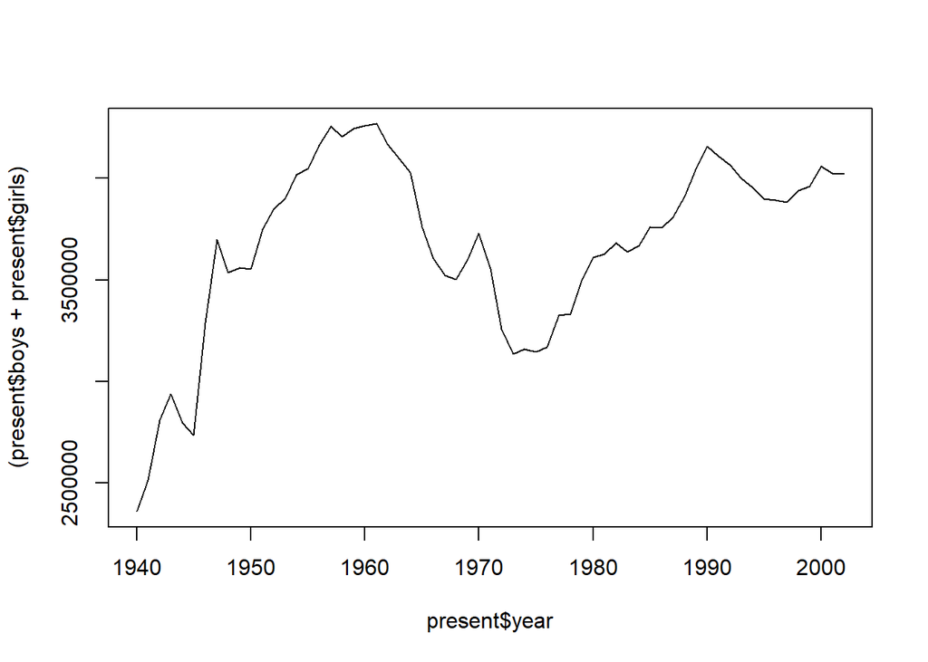

```r
plot(present$year, (present$boys + present$girls), type = "l")
```

Analyzing using calculation, to be more precise

```r
present$year[(present$boys + present$girls) == max(present$boys + present$girls)]
```

```
## [1] 1961
```

Therefore, the year 1961 , it’s the most total number of births in the U.S